# FinalP1

Jonah Smith

2025-04-09

##Load Libraries

```r
library(tidyverse)
```

##Read Data

```r
df <- readr::read_csv("paint_project_train_data.csv", col_names = TRUE)
glimpse(df)
```

```
## Rows: 835
## Columns: 8
## $ R          <dbl> 172, 26, 172, 28, 170, 175, 90, 194, 171, 122, 0, 88, 144, …
## $ G          <dbl> 58, 88, 94, 87, 66, 89, 78, 106, 68, 151, 121, 140, 82, 163…
## $ B          <dbl> 62, 151, 58, 152, 58, 65, 136, 53, 107, 59, 88, 58, 132, 50…
## $ Lightness  <chr> "dark", "dark", "dark", "dark", "dark", "dark", "dark", "da…
## $ Saturation <chr> "bright", "bright", "bright", "bright", "bright", "bright",…
## $ Hue        <dbl> 4, 31, 8, 32, 5, 6, 34, 10, 1, 21, 24, 22, 36, 16, 26, 12, …
## $ response   <dbl> 12, 10, 16, 10, 11, 16, 10, 19, 14, 25, 14, 19, 14, 38, 15,…
## $ outcome    <dbl> 1, 1, 1, 0, 0, 0, 0, 0, 0, 0, 0, 0, 0, 0, 0, 0, 0, 0, 1, 1,…
```

#Part i: Exploration

• Visualize the distributions of variables in the data set.

• Counts for categorical variables.

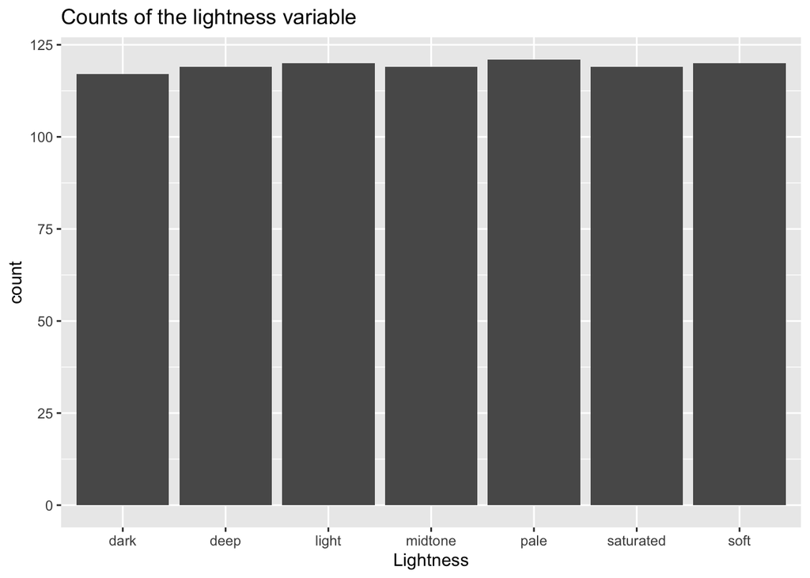

```r
df %>% ggplot(aes(x = Lightness)) + geom_bar(stat = "count") + labs(title = "Counts of the lightness variable")
```

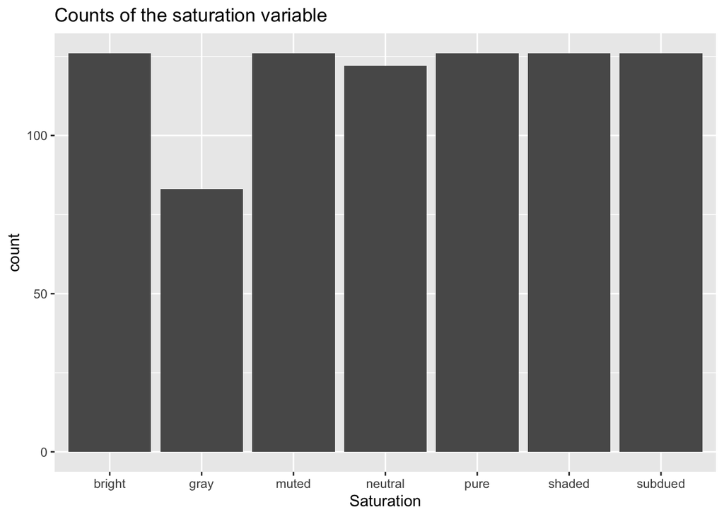

```r
df %>% ggplot(aes(x = Saturation)) + geom_bar(stat = "count") + labs(title = "Counts of the saturation variable")
```

• Histograms or Density plots for continuous variables. Are the distributions Gaussian like?

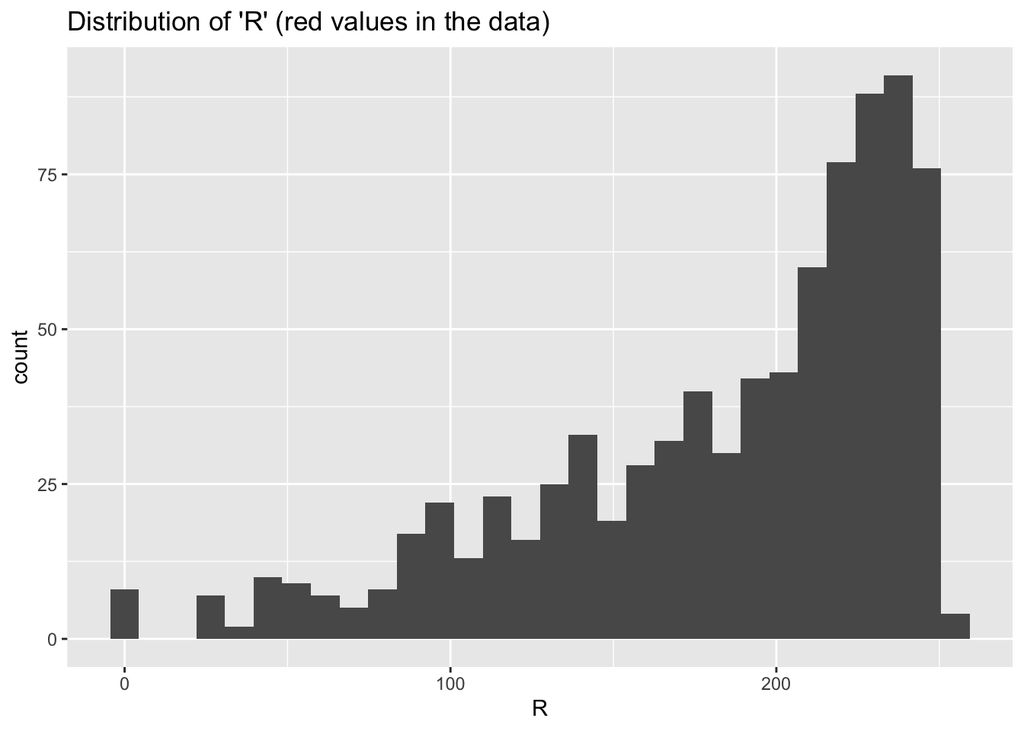

```r
df %>% ggplot(aes(x = R)) + geom_histogram() + labs(title = "Distribution of 'R' (red values in the data)")
```

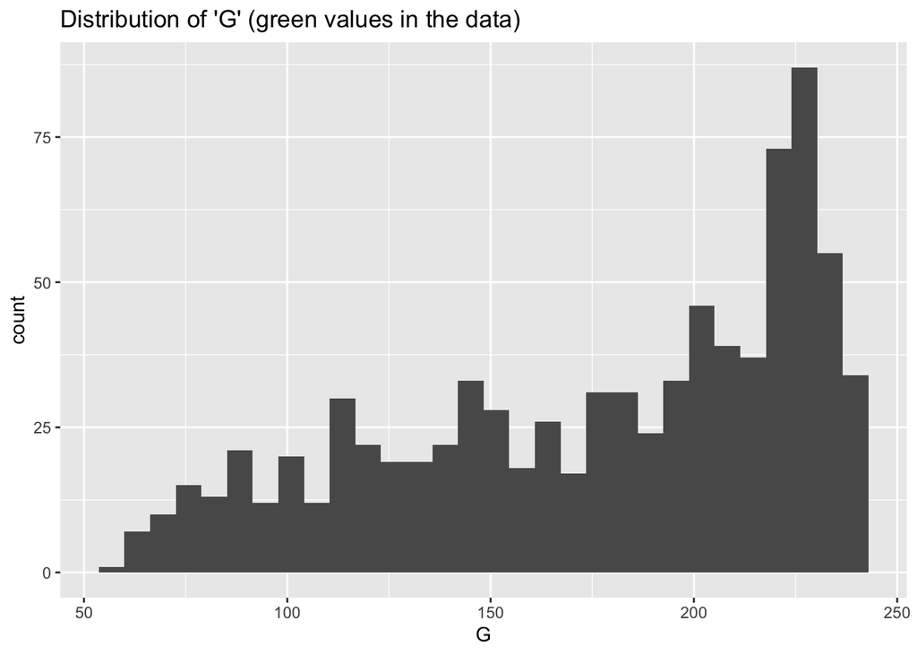

```r
df %>% ggplot(aes(x = G)) + geom_histogram() + labs(title = "Distribution of 'G' (green values in the data)")
```

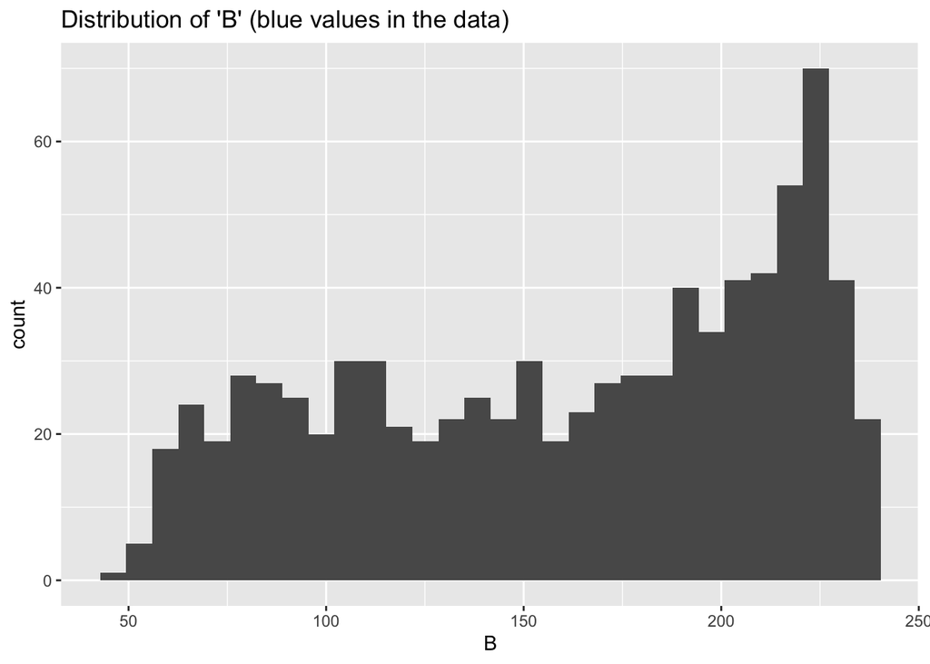

```r
df %>% ggplot(aes(x = B)) + geom_histogram() + labs(title = "Distribution of 'B' (blue values in the data)")
```

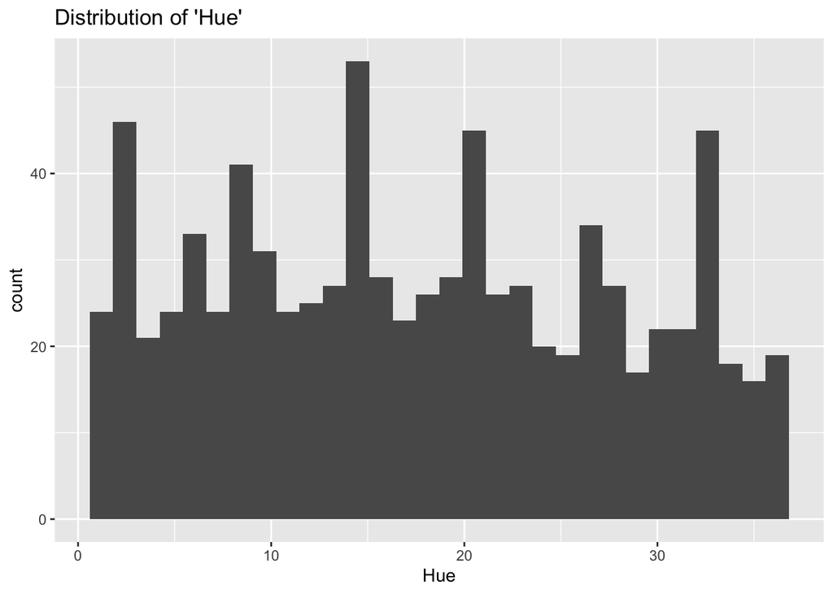

```r
df %>% ggplot(aes(x = Hue)) + geom_histogram() + labs(title = "Distribution of 'Hue'")
```

Both the R, G, and B values seemed to be a (noisy) skewed distribution, with a heavy left tail. Hue seems to have certain common values (ie spikes in the graph), but it looks overall uniform in distribution.

• Condition (group) the continuous variables based on the categorical variables.

COLORS

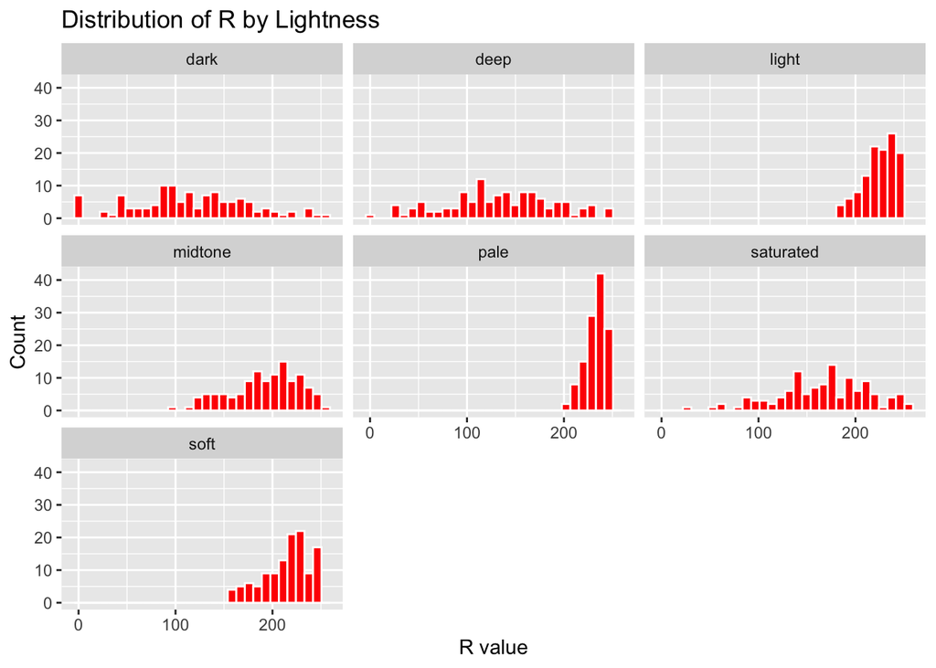

```r
# Histogram of R grouped by Lightness using faceting
df %>%
  ggplot(aes(x = R)) +
  geom_histogram(bins = 30, fill = "red", color = "white") +
  facet_wrap(~ Lightness) +
  labs(title = "Distribution of R by Lightness", x = "R value", y = "Count")
```

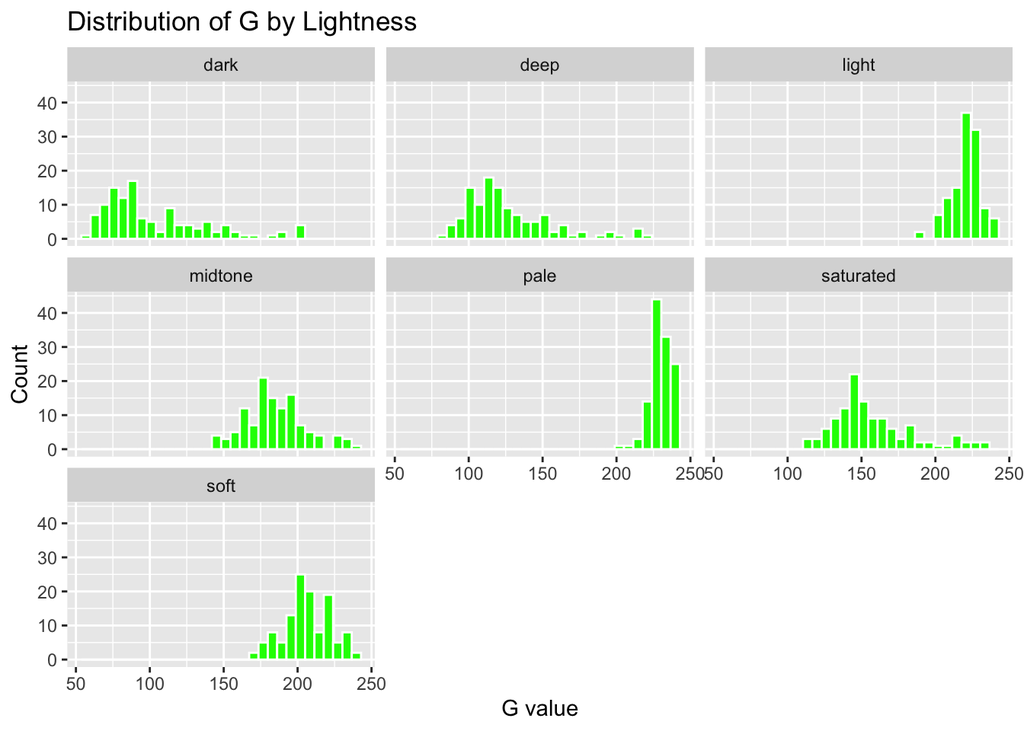

```r
df %>%
  ggplot(aes(x = G)) +
  geom_histogram(bins = 30, fill = "green", color = "white") +
  facet_wrap(~ Lightness) +
  labs(title = "Distribution of G by Lightness", x = "G value", y = "Count")
```

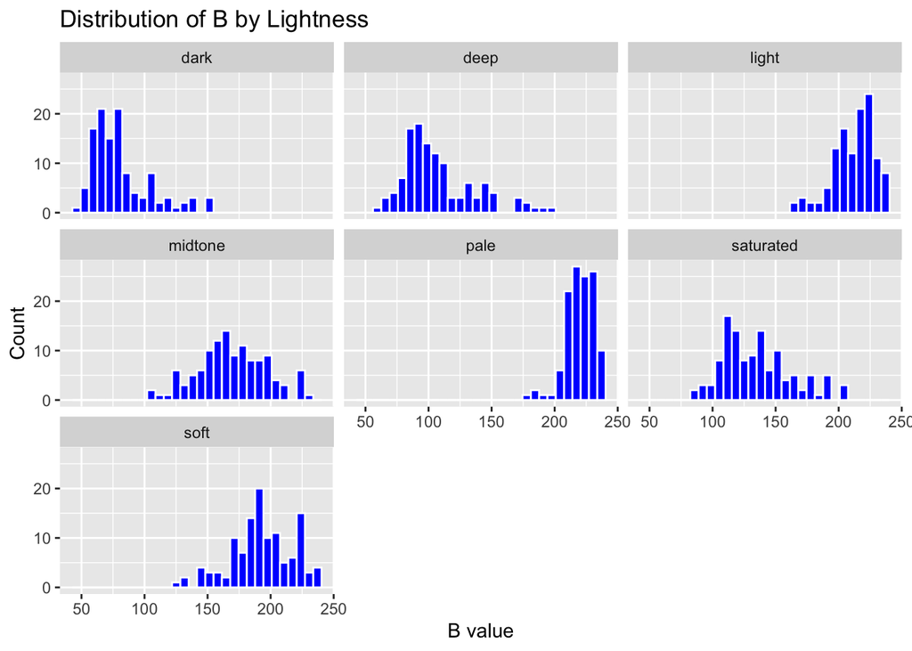

```r
df %>%
  ggplot(aes(x = B)) +
  geom_histogram(bins = 30, fill = "blue", color = "white") +
  facet_wrap(~ Lightness) +
  labs(title = "Distribution of B by Lightness", x = "B value", y = "Count")
```

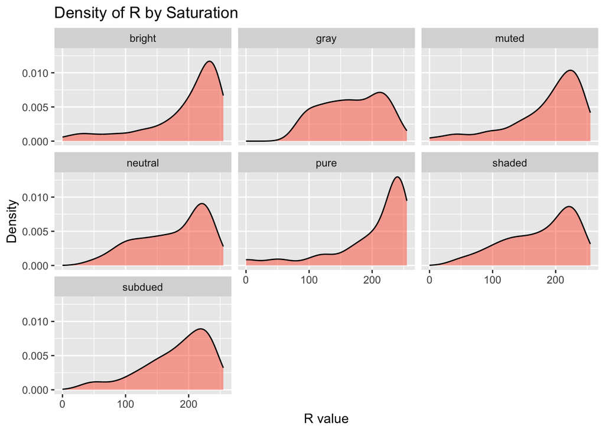

```r
# Density plot of G grouped by Saturation using faceting
df %>%
  ggplot(aes(x = R)) +
  geom_density(fill = "tomato", alpha = 0.5) +
  facet_wrap(~ Saturation) +
  labs(title = "Density of R by Saturation", x = "R value", y = "Density")
```

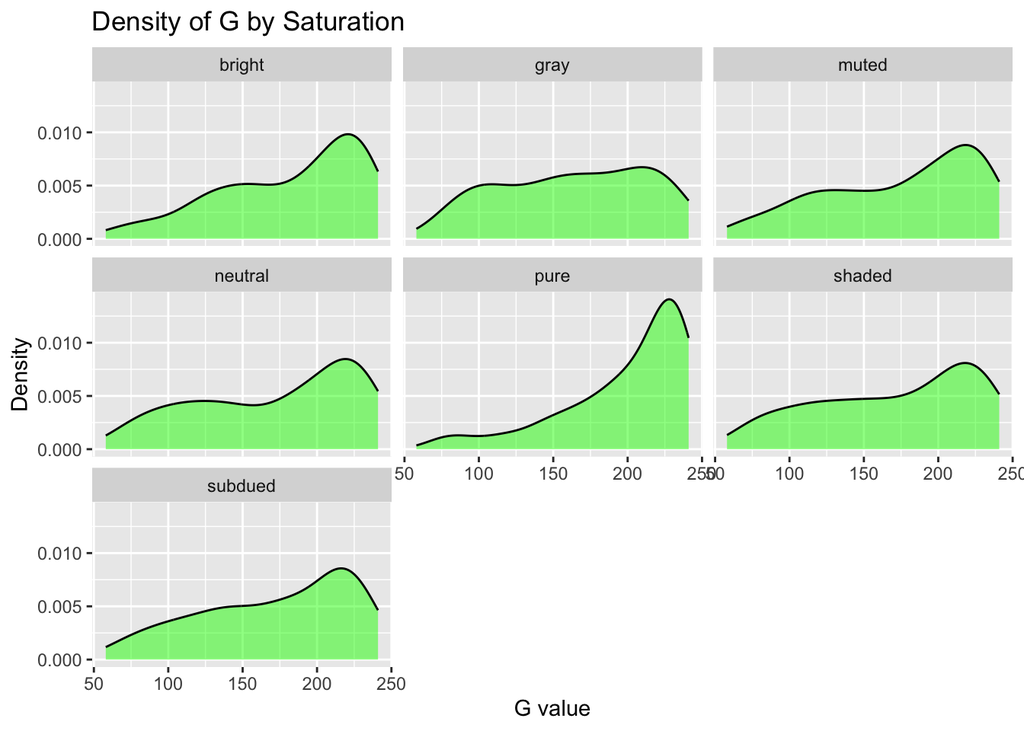

```r
df %>%
  ggplot(aes(x = G)) +
  geom_density(fill = "green", alpha = 0.5) +
  facet_wrap(~ Saturation) +
  labs(title = "Density of G by Saturation", x = "G value", y = "Density")
```

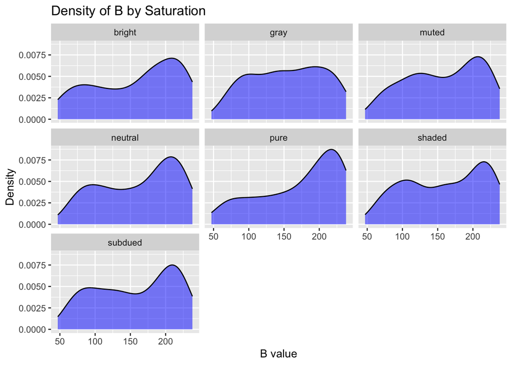

```r
df %>%
  ggplot(aes(x = B)) +
  geom_density(fill = "blue", alpha = 0.5) +
  facet_wrap(~ Saturation) +
  labs(title = "Density of B by Saturation", x = "B value", y = "Density")
```

• Are there differences in continuous variable distributions and continuous variable summary statistics based on categorical variable values?

STRATIFIED BY LIGHTNESS

- R stratified by Lightness - Noisy but potentially gaussian - Dark, deep, saturated Clean distributions (looks to be little noise) - light, midtone, pale, soft
- G stratified by Lightness - potentially gaussian - dark, deep, midtone, saturated, soft light might be gaussian, but contains some outlier values
- B stratified by Lightness - Noisy but potentially gaussian - midtone, saturated, soft
- IN AGGREGATE
  - THE COLORS BY LIGHTNESS SEEM TO HAVE DISTRIBUTIONS THAT WERE PREVIOUSLY NOT SEEN IN AGGREGATE
  - there are many seemingly gaussian distributions that appear when you group color by lightness level, and this could be useful in making predictions

STRATIFIED BY SATURATION

- R by Saturation
  - almost all of the saturation values seem to be normal with an extreme left skew “gray” saturation has more in the middle than expected if it followed a left skew normal dist
- G by Saturation
  - similar to R by saturation, most of the distributions seem to have large left tails.
  - grey seems to be more centered around the mean (~150) as well
- B by Saturation
  - many of these distributions have a bi-modal shape. There is a peak around the ~50-100 region, and then another around the ~200 region.
  - grey, again, seems to be more centered around the mean
- IN AGGREGATE
  - by saturation, each of the colors individually seem to have the most values around the ~200 saturation level. Blue tends to have more values in the lower saturation than either red or green.

HUE GROUPED BY CATEGORICAL

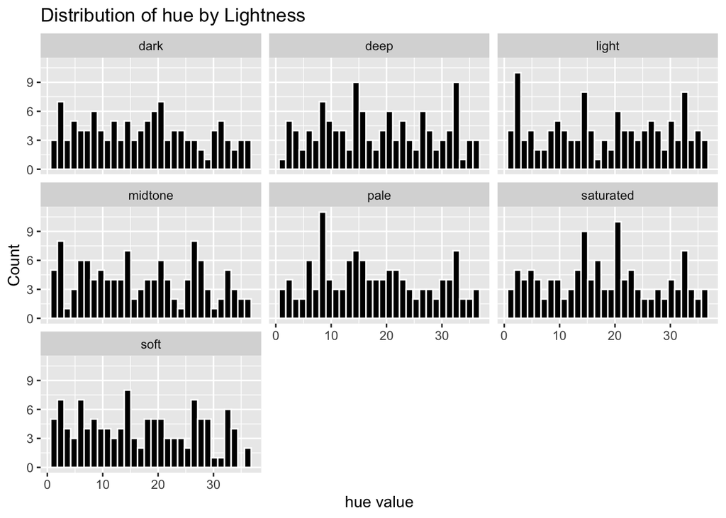

```r
df %>%
  ggplot(aes(x = Hue)) +
  geom_histogram(bins = 30, fill = "black", color = "white") +
  facet_wrap(~ Lightness) +
  labs(title = "Distribution of hue by Lightness", x = "hue value", y = "Count")
```

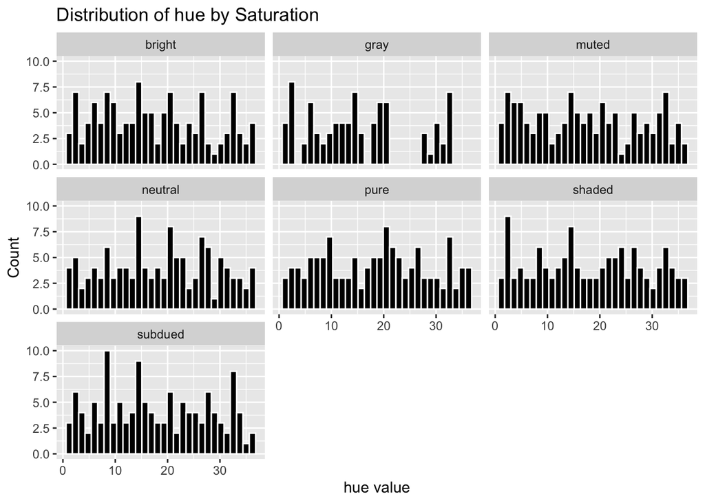

```r
df %>%
  ggplot(aes(x = Hue)) +
  geom_histogram(bins = 30, fill = "black", color = "white") +
  facet_wrap(~ Saturation) +
  labs(title = "Distribution of hue by Saturation", x = "hue value", y = "Count")
```

- These values look to be largely uniform distributions with lots of noise. It will be hard to gain predictive insight from hue when stratified by the Lightness or Saturation value.

• Are there differences in continuous variable distributions and continuous variable summary statistics based on the binary outcome?

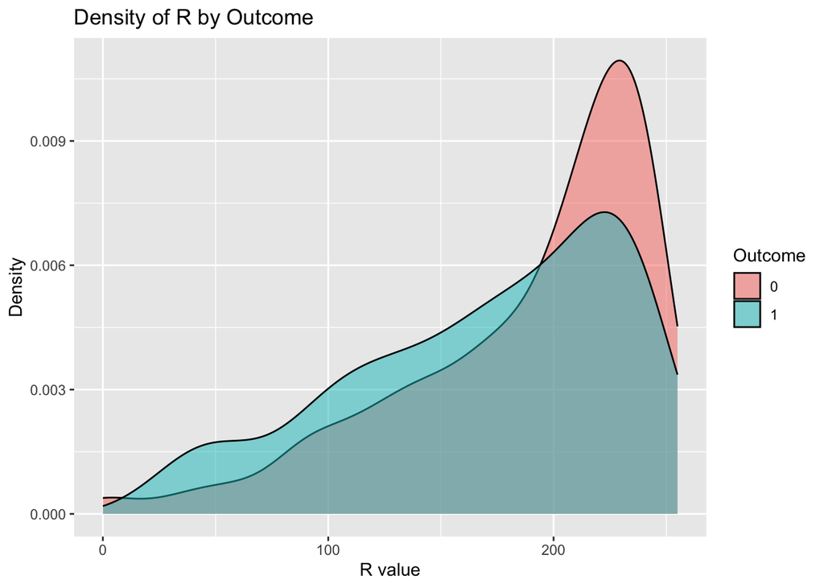

```r
df %>%
  ggplot(aes(x = R, fill = as.factor(outcome))) +
  geom_density(alpha = 0.5) +
  labs(title = "Density of R by Outcome", x = "R value", y = "Density", fill = "Outcome")
```

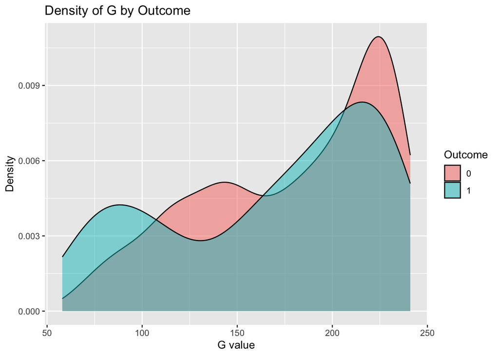

```r
df %>%
  ggplot(aes(x = G, fill = as.factor(outcome))) +
  geom_density(alpha = 0.5) +
  labs(title = "Density of G by Outcome", x = "G value", y = "Density", fill = "Outcome")
```

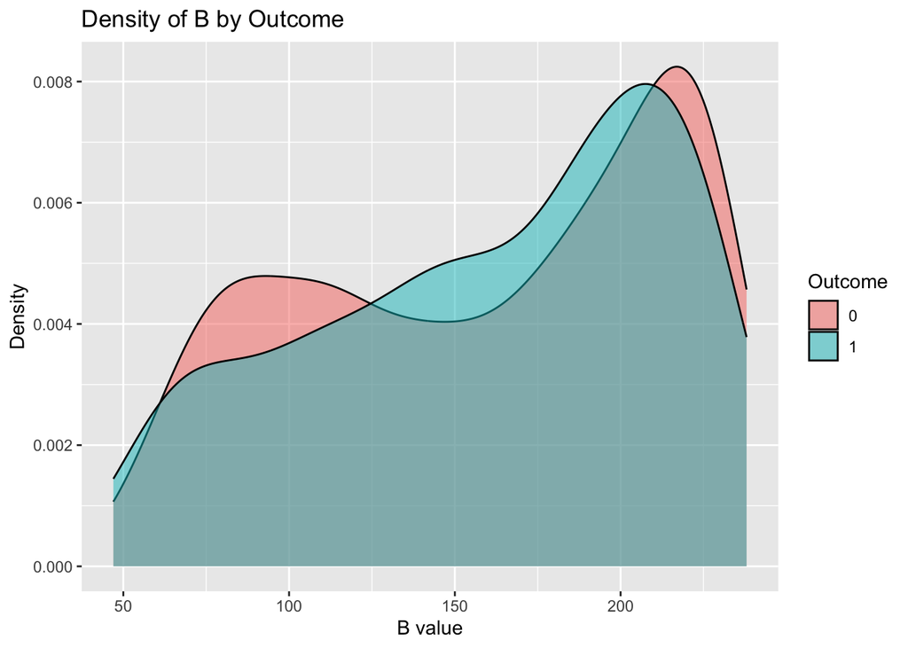

```r
df %>%
  ggplot(aes(x = B, fill = as.factor(outcome))) +
  geom_density(alpha = 0.5) +
  labs(title = "Density of B by Outcome", x = "B value", y = "Density", fill = "Outcome")
```

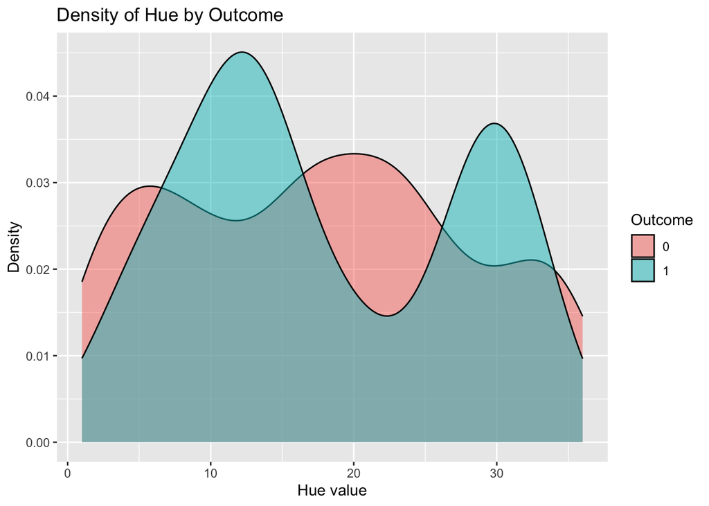

```r
df %>%
  ggplot(aes(x = Hue, fill = as.factor(outcome))) +
  geom_density(alpha = 0.5) +
  labs(title = "Density of Hue by Outcome", x = "Hue value", y = "Density", fill = "Outcome")
```

R BY OUTCOME

- Both the 0 and 1 outcome seem to have a similar distribution, the 0 outcomes have a higher density amongst high r values, but the general shape and mode of both distributions are similar.

G BY OUTCOME

- Low values (50-100) of G have a higher density in the 1 outcome. Values in the (~100-160) range have the opposite pattern, higher density of 0 than of 1. the upper values seem to be very similar when stratified by outcome.

B BY OUTCOME

- the shape of these distributions are very similar. Blue distribution with outcome 0 seems to be bi-modal, with a first peak around 80, where outcome 1’s stratification seems to be unimodal. both peaks in the high range of B are around 210.

HUE BY OUTCOME

- this plot seems to be the most interesting of them all. Hue by 0 seems to be inversely correlated with hue by 1 outcomes. This means, at least it appears visually, as the density of Hue goes up when looking at just 0 outcomes, the density of the hue with 1 outcomes goes down. Since the two distributions are very different, looking at the relative densities of the two could provide a useful insight in predicting outcome with just a hue value. This can be used as part of a larger model, but it seems to be a promising idea.

• Visualize the relationships between the continuous inputs, are they correlated?

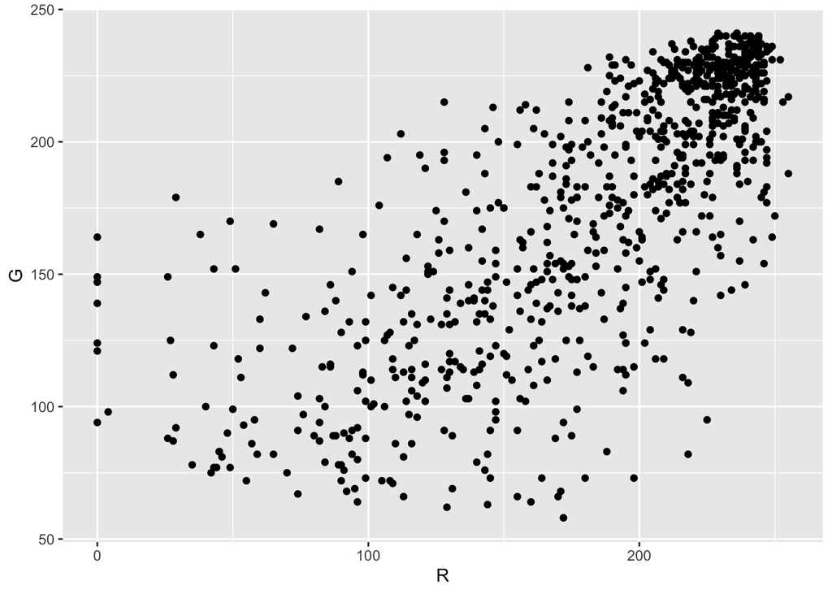

```r
df %>% ggplot(aes(x = R, y = G)) + geom_point()
```

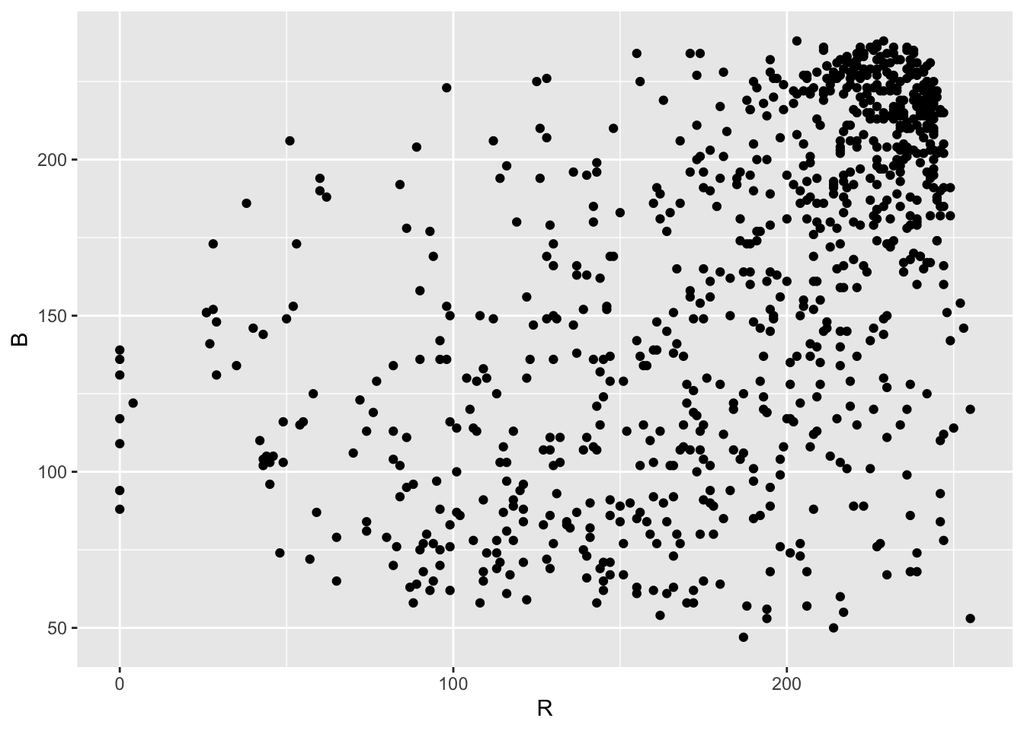

```r
df %>% ggplot(aes(x = R, y = B)) + geom_point()
```

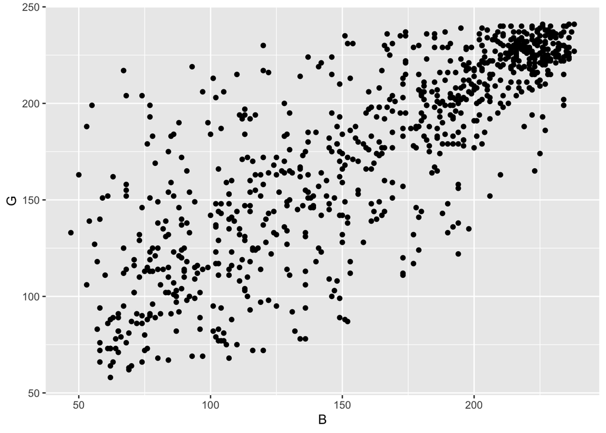

```r
df %>% ggplot(aes(x = B, y = G)) + geom_point()
```

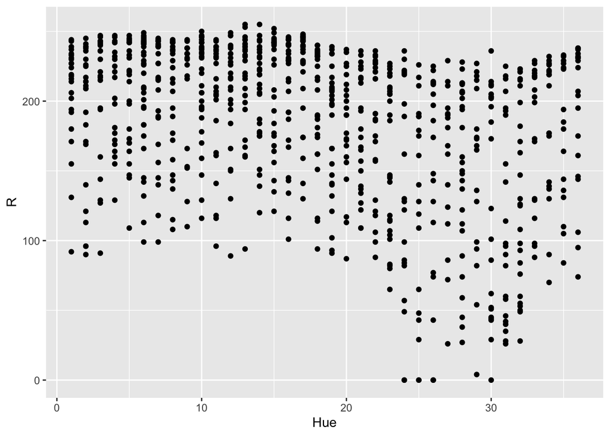

```r
df %>% ggplot(aes(x = Hue, y = R)) + geom_point()
```

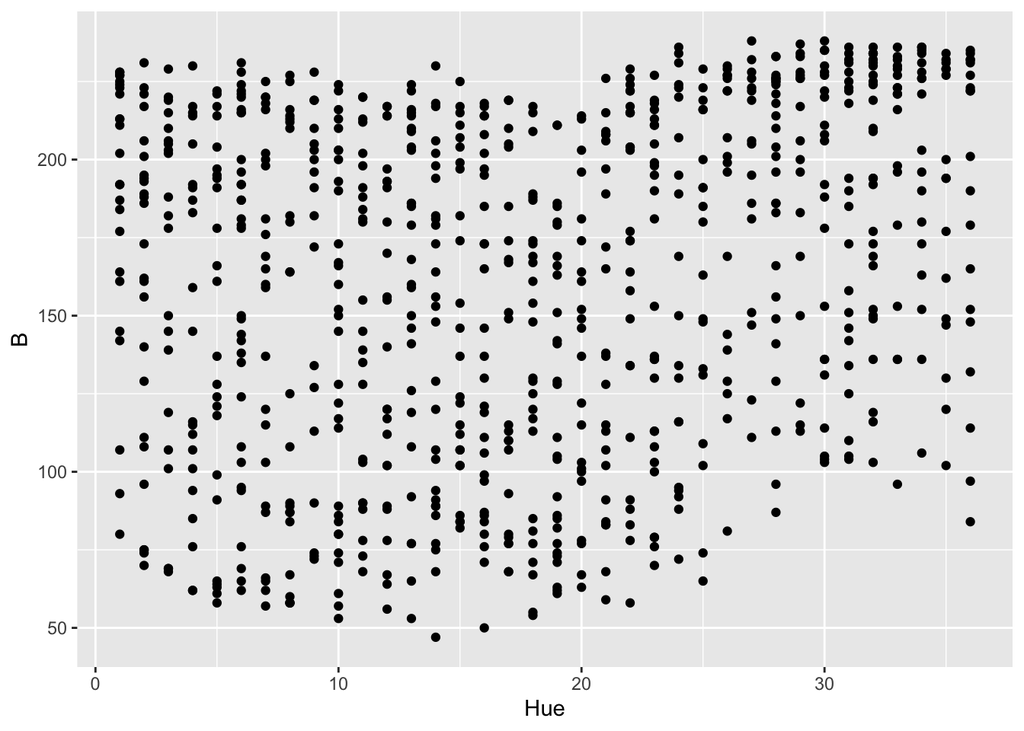

```r
df %>% ggplot(aes(x = Hue, y = B)) + geom_point()
```

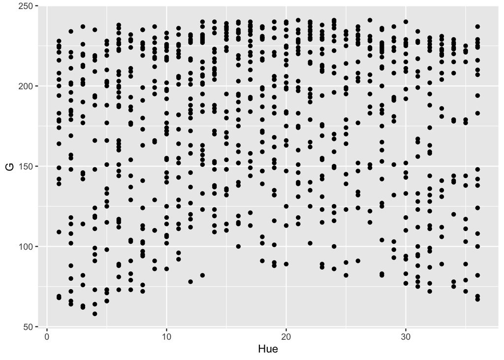

```r
df %>% ggplot(aes(x = Hue, y = G)) + geom_point()
```

Relationships between continuous variables:

Red and Green: seems to have a certain relationship, but it looks non linear. Could be quadratic or of another nature.

Red and Blue: seems to have little to no relationship.

Blue and Green: seems to have a linear relationship.

Hue and the colors do not seem to produce a graph that looks more than noise.

• Visualize the relationships between the continuous outputs (response and the LOGIT-transformed response, y) with respect to the continuous INPUTS.

```r
dfii <- df %>%
  mutate(y = boot::logit( (response - 0) / (100 - 0) ) ) %>%
  select(R, G, B,
         Lightness, Saturation, Hue, response,
         y)


dfii %>% glimpse()
```

```
## Rows: 835
## Columns: 8
## $ R          <dbl> 172, 26, 172, 28, 170, 175, 90, 194, 171, 122, 0, 88, 144, …
## $ G          <dbl> 58, 88, 94, 87, 66, 89, 78, 106, 68, 151, 121, 140, 82, 163…
## $ B          <dbl> 62, 151, 58, 152, 58, 65, 136, 53, 107, 59, 88, 58, 132, 50…
## $ Lightness  <chr> "dark", "dark", "dark", "dark", "dark", "dark", "dark", "da…
## $ Saturation <chr> "bright", "bright", "bright", "bright", "bright", "bright",…
## $ Hue        <dbl> 4, 31, 8, 32, 5, 6, 34, 10, 1, 21, 24, 22, 36, 16, 26, 12, …
## $ response   <dbl> 12, 10, 16, 10, 11, 16, 10, 19, 14, 25, 14, 19, 14, 38, 15,…
## $ y          <dbl> -1.9924302, -2.1972246, -1.6582281, -2.1972246, -2.0907411,…
```

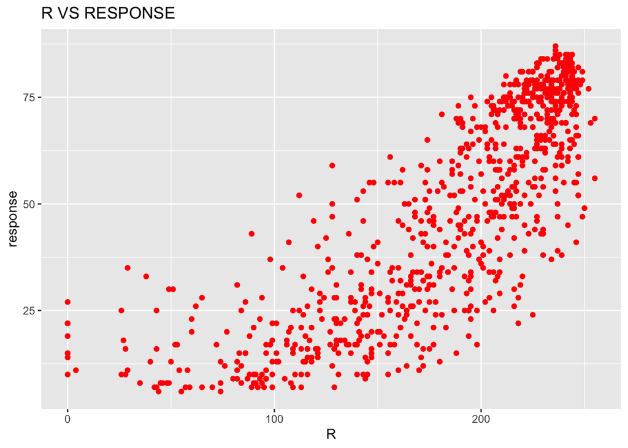

```r
dfii %>% ggplot(aes(x = R, y = response)) + geom_point(color = "red") + labs(title = "R VS RESPONSE")
```

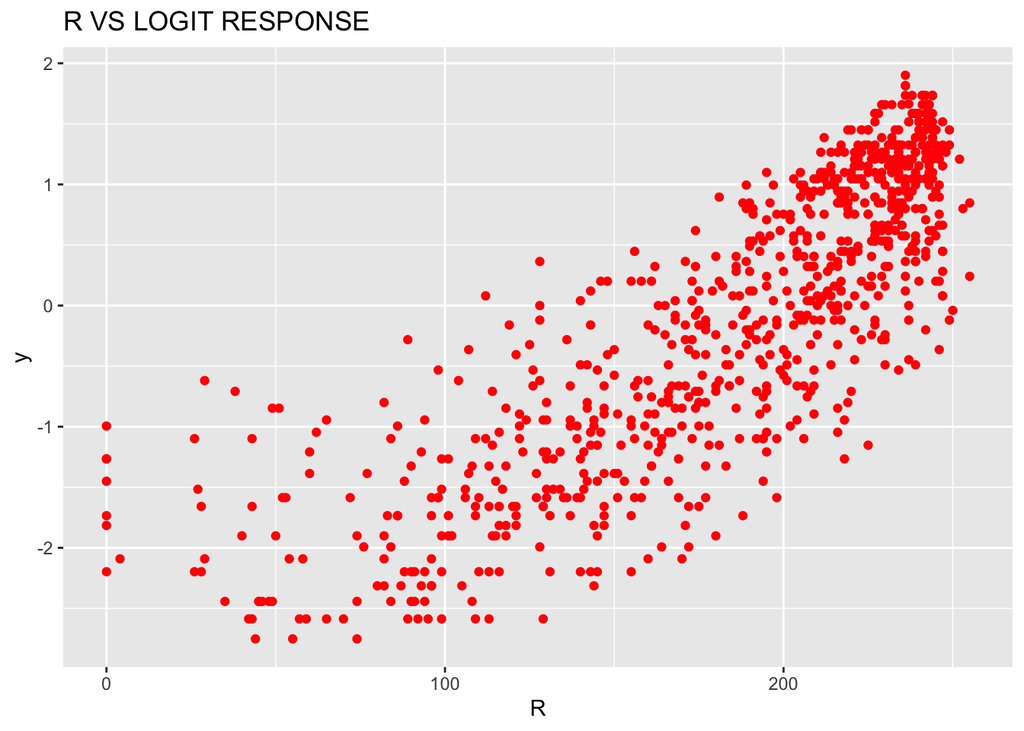

```r
dfii %>% ggplot(aes(x = R, y = y)) + geom_point(color = "red") + labs(title = "R VS LOGIT RESPONSE")
```

Red seems to have a quadratic or other non linear relationship with logit response. The relationship seems less obvious when compared with non-transformed response.

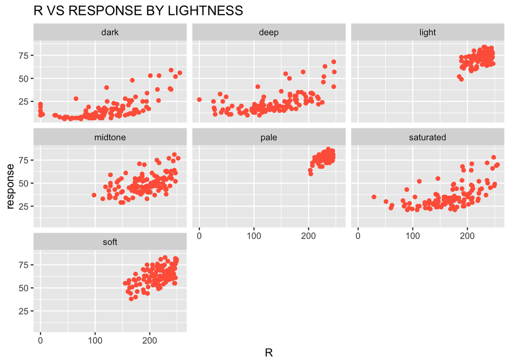

```r
dfii %>% ggplot(aes(x = R, y = response)) + geom_point(color = "tomato") + facet_wrap(~ Lightness) + labs(title = "R VS RESPONSE BY LIGHTNESS")
```

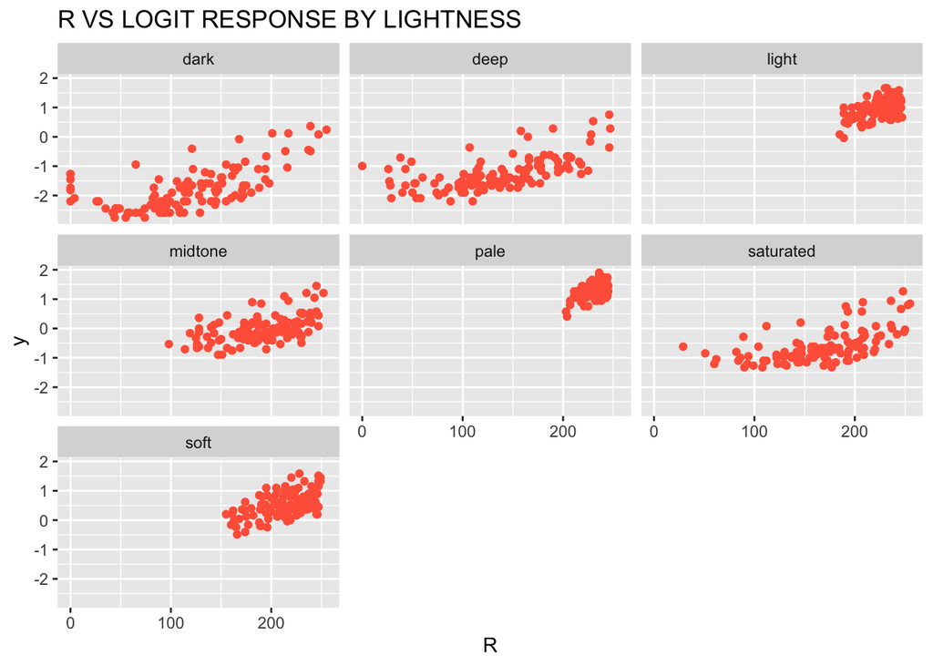

```r
dfii %>% ggplot(aes(x = R, y = y)) + geom_point(color = "tomato") + facet_wrap( ~Lightness) + labs(title = "R VS LOGIT RESPONSE BY LIGHTNESS")
```

When grouped by lightness, certain lightness levels (light, pale, soft) have formed clusters, meaning that for a paint with this lightness level, there is a relatively small range that both the response and the color will be in.

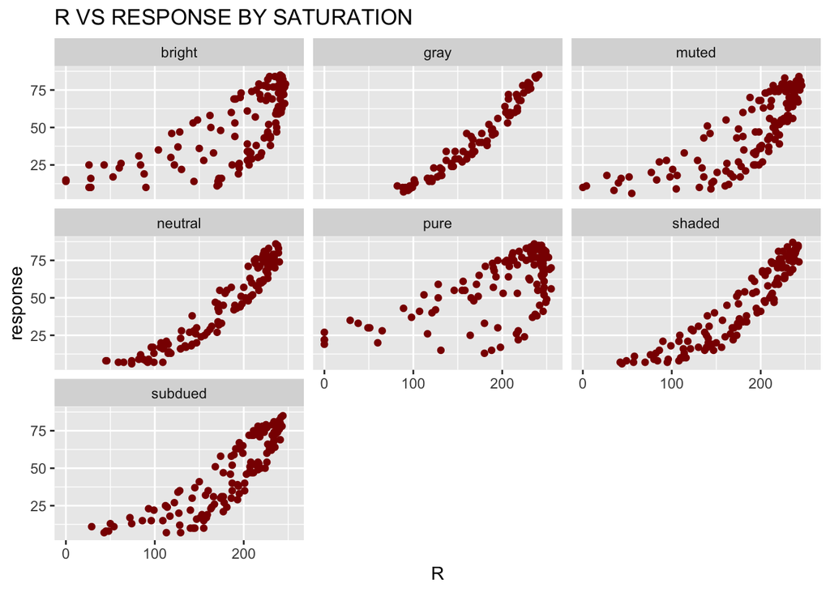

```r
dfii %>% ggplot(aes(x = R, y = response)) + geom_point(color = "darkred") + facet_wrap(~ Saturation) + labs(title = "R VS RESPONSE BY SATURATION")
```

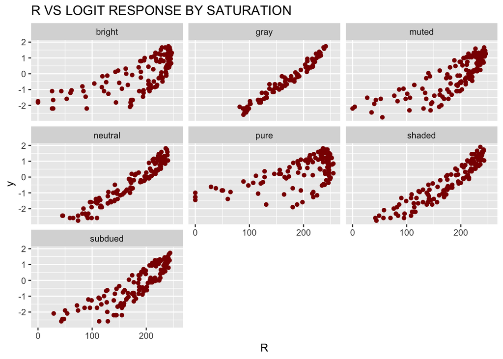

```r
dfii %>% ggplot(aes(x = R, y = y)) + geom_point(color = "darkred") + facet_wrap(~ Saturation) + labs(title = "R VS LOGIT RESPONSE BY SATURATION")
```

When grouped by saturation, certain saturation levels show a very linear relationship between red and logit response (this applies to neutral, gray, and shaded). The other satuartion levels seem to fit a sort of tilted parabolic shape.

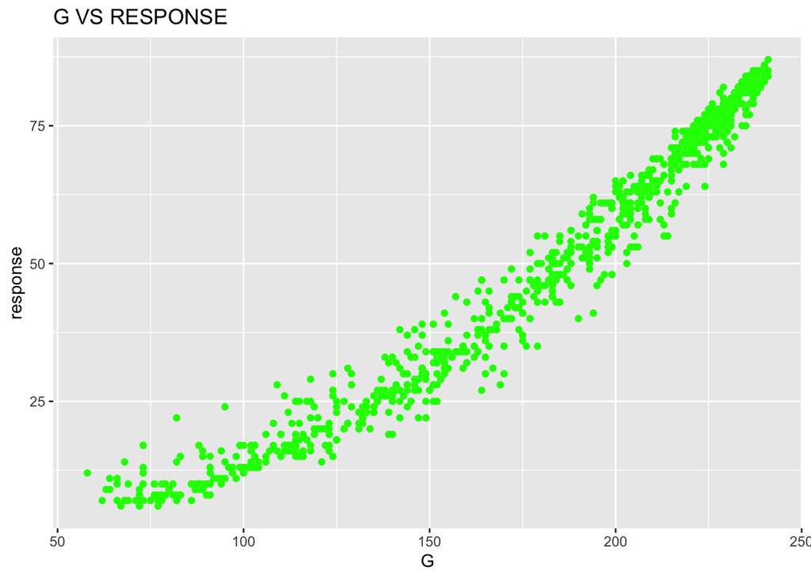

```r
dfii %>% ggplot(aes(x = G, y = response)) + geom_point(color = "green") + labs(title = "G VS RESPONSE")
```